# Course Project 1

Anh Nguyen

Date: 23-12-2022

#### 1. Code for reading in the dataset and processing the data

```r
df <- read.csv("activity.csv", sep = ",")
str(df)
```

```
## 'data.frame':    17568 obs. of  3 variables:
##  $ steps   : int  NA NA NA NA NA NA NA NA NA NA ...
##  $ date    : chr  "2012-10-01" "2012-10-01" "2012-10-01" "2012-10-01" ...
##  $ interval: int  0 5 10 15 20 25 30 35 40 45 ...
```

```r
df$date <- as.Date(df$date, format= "%Y-%m-%d")
```

#### 2. Histogram of the total number of steps taken each day

```r
library(dplyr)
```

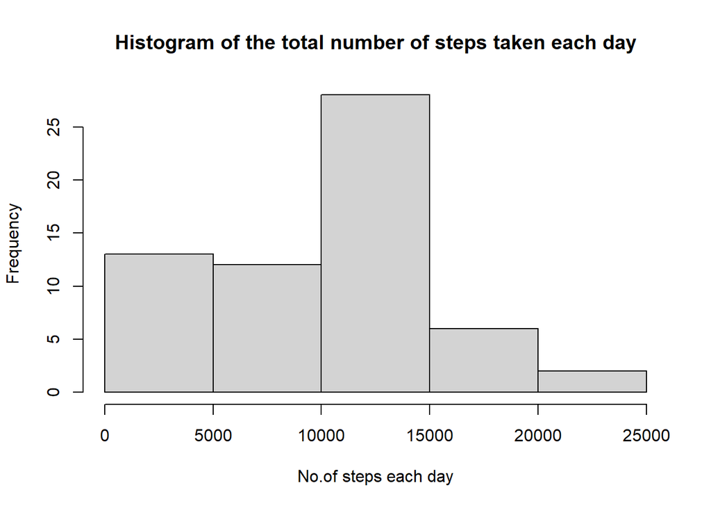

```r
library(dplyr)
temp <- df %>% group_by(date) %>% summarise(totalstep = sum(steps, na.rm = T))

hist(temp$totalstep, xlab = "No.of steps each day", main = "Histogram of the total number of steps taken each day")
```

#### 3. Mean and median number of steps taken each day

```r
mean(temp$totalstep)
```

```
## [1] 9354.23
```

```r
median(temp$totalstep)
```

```
## [1] 10395
```

#### 4.Time series plot of the average number of steps taken

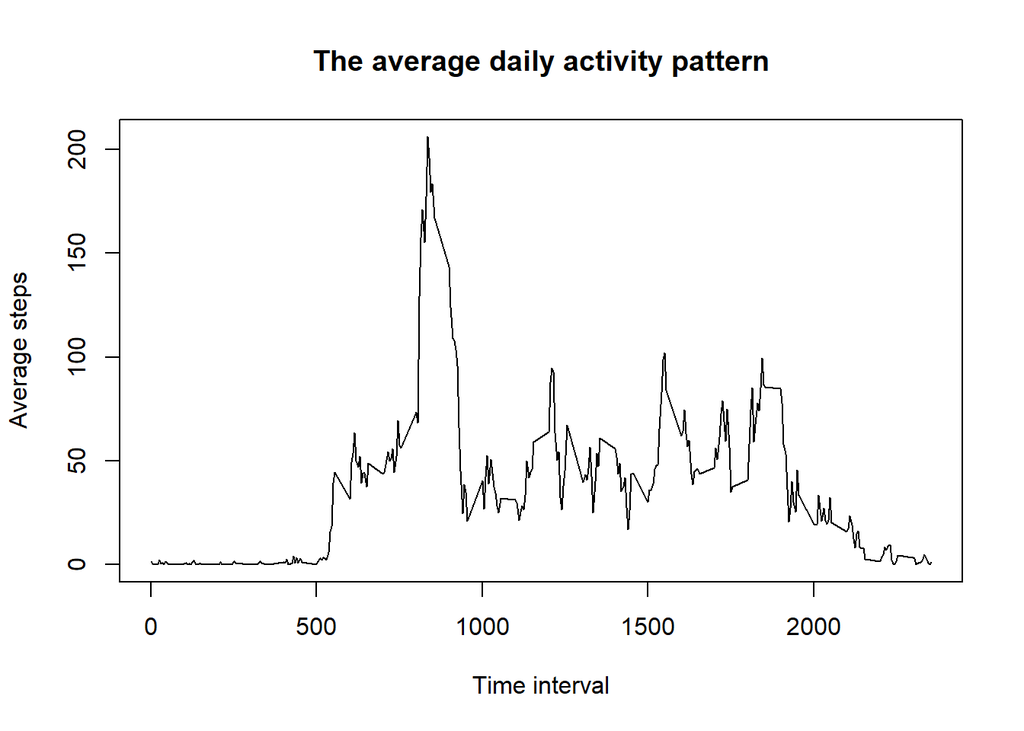

```r
temp <- df %>% group_by(interval) %>% summarise(average_step_interval = mean(steps, na.rm = T))

with(temp, plot(interval, average_step_interval, type="l", xlab="Time interval", ylab="Average steps", main="The average daily activity pattern"))
```

#### 5. The 5-minute interval that, on average, contains the maximum number of steps:835

```r
temp$interval[temp$average_step_interval == max(temp$average_step_interval )]
```

```
## [1] 835
```

#### 6. Code to describe and show a strategy for imputing missing data

- The total number of missing values in the dataset (i.e. the total number of rows with NAs): 2304

```r
sapply(df, function(x) sum(is.na(x)))
```

```
##    steps     date interval
##     2304        0        0
```

```r
sum(is.na(df$steps))
```

```
## [1] 2304
```

- A strategy for filling in all of the missing values in the dataset: NA values will be filled by the mean for that 5-minute interval.A new dataset that is equal to the original dataset but with the missing data filled in:

```r
newdf <- merge(df, temp, by = "interval", all.x = T)
newdf <- newdf %>% mutate(new_steps = ifelse(is.na(steps), average_step_interval, steps))
```

- New mean and median total number of steps taken per day:

```r
temp <- newdf %>% group_by(date) %>% summarise(new_totalstep = sum(new_steps, na.rm = T), totalstep = sum(steps, na.rm = T))
mean(temp$new_totalstep)
```

```
## [1] 10766.19
```

```r
median(temp$new_totalstep)
```

```
## [1] 10766.19
```

- Do these values differ from the estimates from the first part of the assignment? YES
- What is the impact of imputing missing data on the estimates of the total daily number of steps?: Imputing missing data has led to an increase in both mean and median of the estimates of the total daily number of steps

#### 7. Histogram of the total number of steps taken each day after missing values are imputed

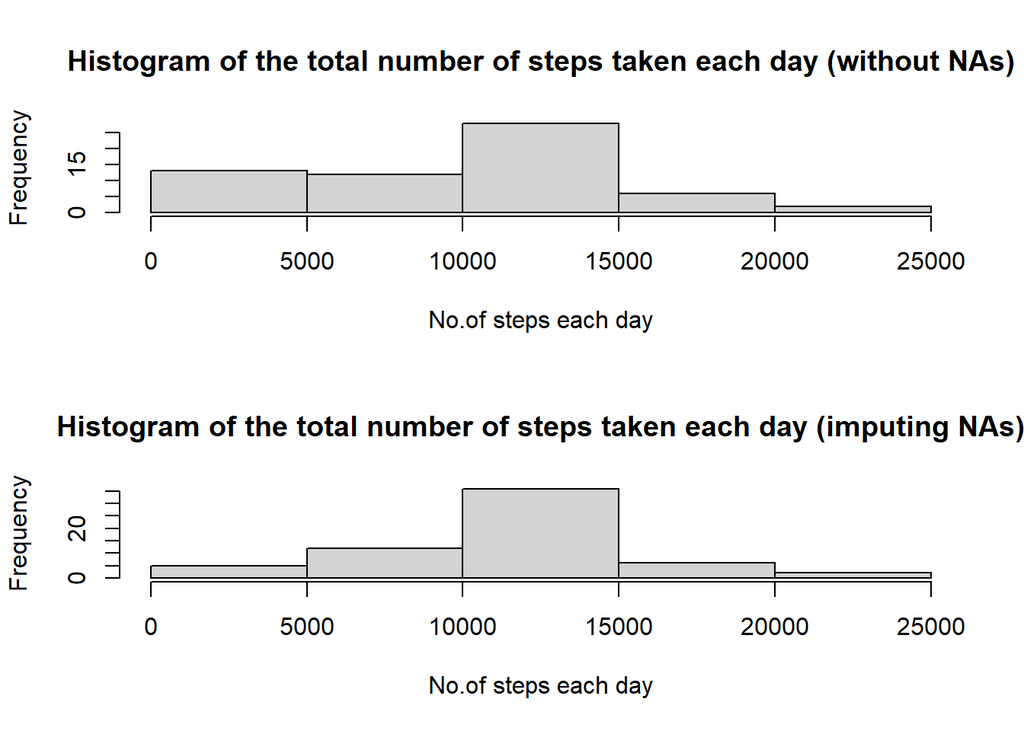

```r
par(mfrow=c(2,1))

hist(temp$totalstep, xlab = "No.of steps each day", main = "Histogram of the total number of steps taken each day (without NAs)")
hist(temp$new_totalstep, xlab = "No.of steps each day", main = "Histogram of the total number of steps taken each day (imputing NAs)")
```

#### 8. Panel plot comparing the average number of steps taken per 5-minute interval across weekdays and weekends

```r
library(lattice)
newdf <- newdf %>% mutate(dayoftheweek = weekdays(date)) %>%
        mutate(day_group = ifelse(dayoftheweek %in% c("Saturday", "Sunday"), "weekend", "weekday" )) %>%
        mutate(day_group = as.factor(day_group))
temp <- newdf %>% group_by(interval, day_group) %>% summarise(average_step = mean(steps, na.rm = T))
```

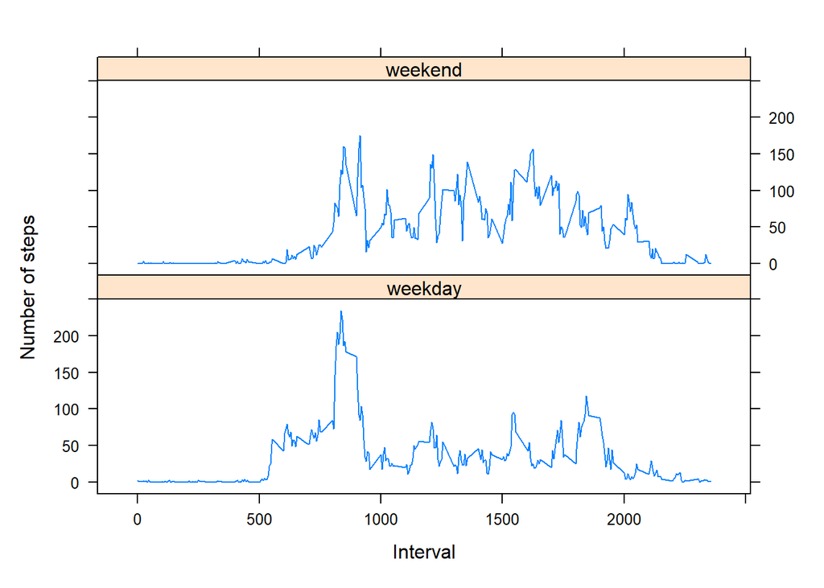

```r
xyplot(average_step ~ interval| day_group, data = temp, layout=c(1,2), type = "l",
       ylab = "Number of steps", xlab = "Interval")
```